# Introdução ao Tidyverse

# Exercicio *Visualizing population*

A histogram is useful for examining the distribution of a numeric variable. In this exercise, you’ll create a histogram showing the distribution of country populations (by millions) in the year 1952.

Code for generating this dataset, gapminder_1952, is provided.

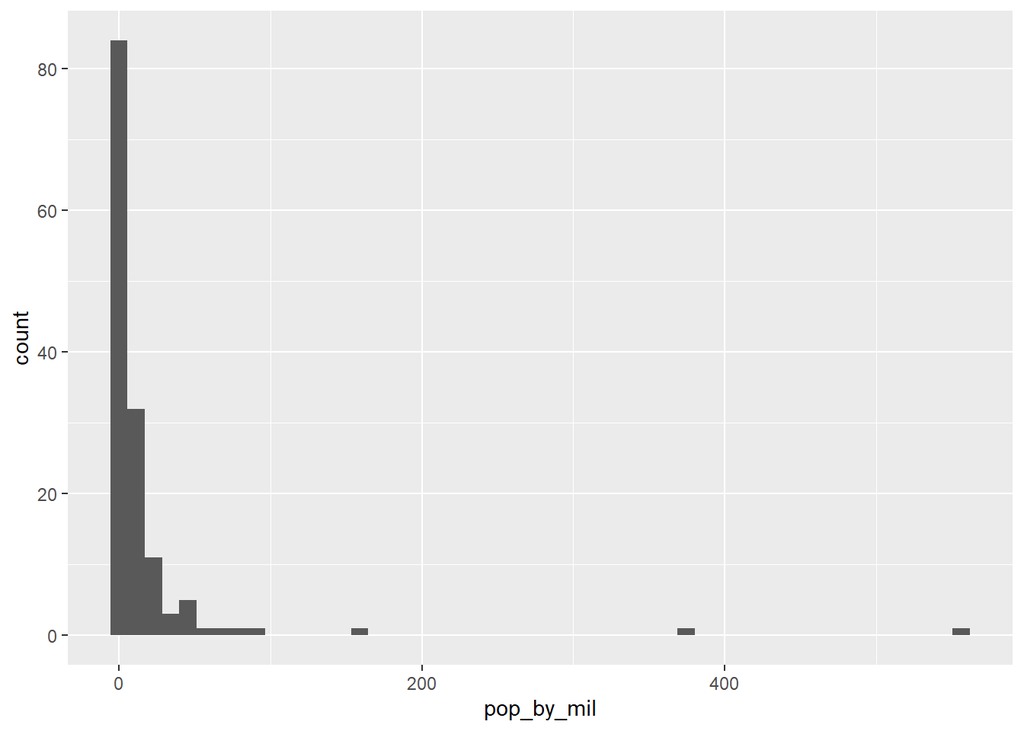

```r
# Use the gapminder_1952 dataset to create a histogram of country population (pop_by_mil) in the year 1952. Inside the histogram geom, set the number of bins to 50.

gapminder_1952 <- gapminder %>%
  filter(year == 1952) %>%
  mutate(pop_by_mil = pop / 1000000)

# Create a histogram of population (pop_by_mil)
ggplot(gapminder_1952, aes(x = pop_by_mil)) +
geom_histogram(bins = 50)
```

# Exercicio *Visualizing population with x-axis on a log scale*

In the last exercise you created a histogram of populations across countries. You might have noticed that there were several countries with a much higher population than others, which causes the distribution to be very skewed, with most of the distribution crammed into a small part of the graph. (Consider that it’s hard to tell the median or the minimum population from that histogram).

To make the histogram more informative, you can try putting the x-axis on a log scale.

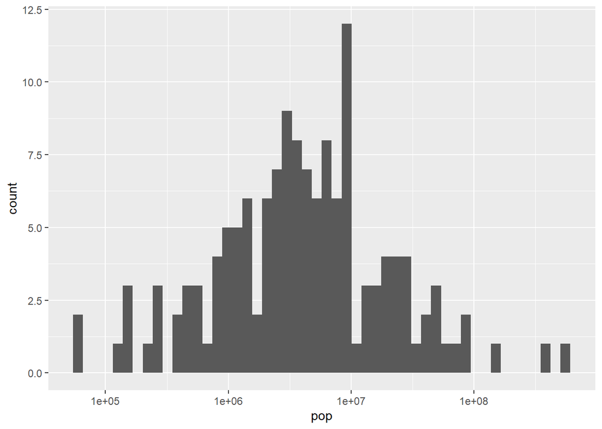

```r
# Use the gapminder_1952 dataset (code is provided) to create a histogram of country population (pop) in the year 1952, putting the x-axis on a log scale with scale_x_log10().

gapminder_1952 <- gapminder %>%
  filter(year == 1952)

# Create a histogram of population (pop), with x on a log scale
ggplot(gapminder_1952, aes(x = pop)) +
      geom_histogram(bins = 50) +
      scale_x_log10()
```

# BOX PLOTS

Antes lembre-se que usamos o histograma quando queríamos examinar a distribuicao de *uma variavel*, da expectativa de vida, em todos os paises. O histograma combina todas as expectativas de vida em todos os continentes, sem distingui-las.

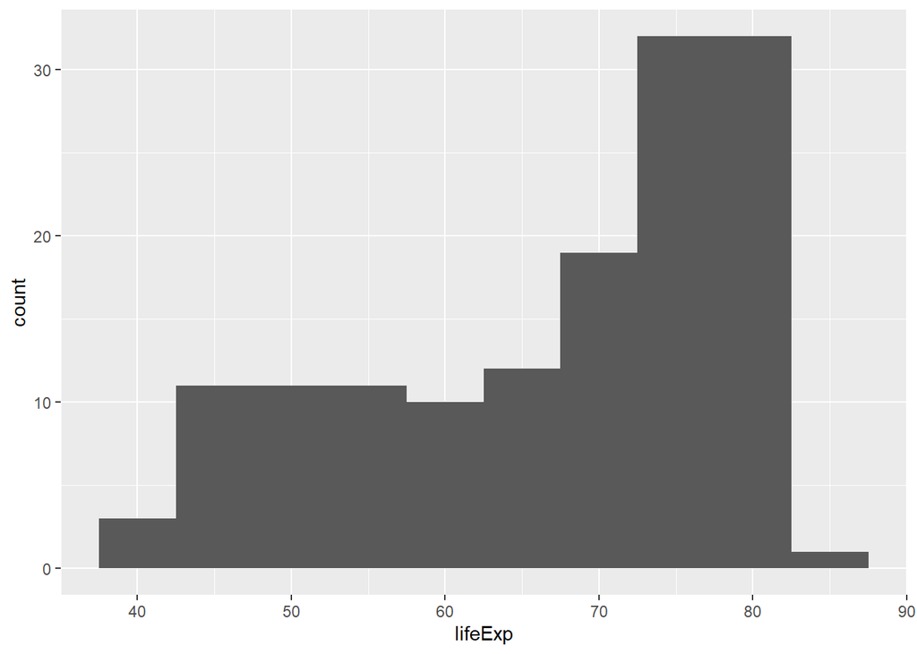

```r
ggplot(gapminder_2007, aes(x = lifeExp)) +
  geom_histogram(binwidth = 5)
```

Mas e se desejarmos comparar a distribuicao das expectativas de vida entre os *continentes*?

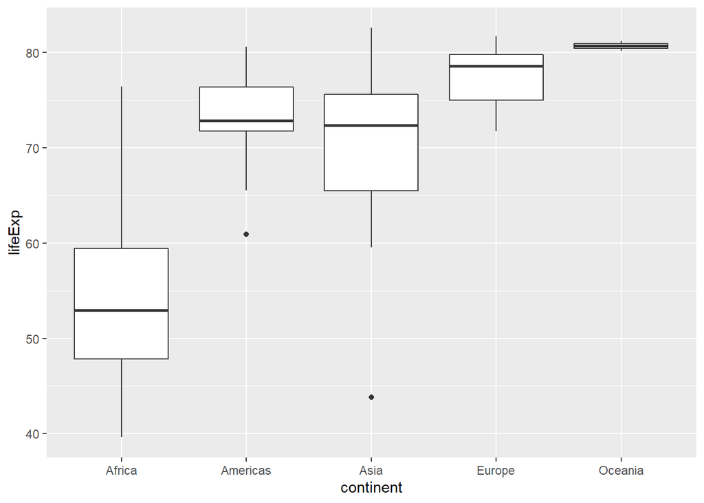

```r
ggplot(gapminder_2007, aes(x = continent, y = lifeExp)) +
  geom_boxplot()
```

```r
# este é um gráfico que mostra a distribuicao das expectativas de vida dentro de cada continent, para que voce possa compara-la.

# observe: x = continentes (categoria)
#          y = os valores de expectativa de vida
```

Um grafico de caixa requer um pouco de pratica para interpretar. No exemplo acima temos:

- A *linha preta* no meio de cada caixa é a *mediana* da distribuicao de *cada continente*.
- As partes superior e inferior de cada caixa representam o 75º percentil e o 25º percentil desse grupo, ou seja, metade da distribuicao está dentro dessa caixa. _ As *linhas* subindo e descendo das caixas sao chamados de *bigodes* (whiskers) cobrem paises adicionais. _ Os *pontos* abaixo ou acima dos bigodes representam valores extremos. Ou seja, paises com expectativa de vida exponencialmente baixa em relacao ao restante da distribuicao.

Portanto, ha muita coisa que esse enredo nos fala sobre diferencas na expectativa de vida nos continentes. Podemos ver que a expectativa média de vida da Europa é uma das mais altas e que os paises da Oceania tem valores muito altos. E tambem podemos ver que a distribuicao para a Africa e extraordinariamente baixa, com cerca da metade de seus paises tendo uma expectativa media de vida entre 50 e 60 anos.

# Exercicio *Comparing GDP per capita across continents*

A boxplot is useful for comparing a distribution of values across several groups. In this exercise, you’ll examine the distribution of GDP per capita by continent. Since GDP per capita varies across several orders of magnitude, you’ll need to put the y-axis on a log scale.

Use the gapminder_1952 dataset (code is provided) to create a boxplot comparing GDP per capita (gdpPercap) among continents. Put the y-axis on a log scale with scale_y_log10().

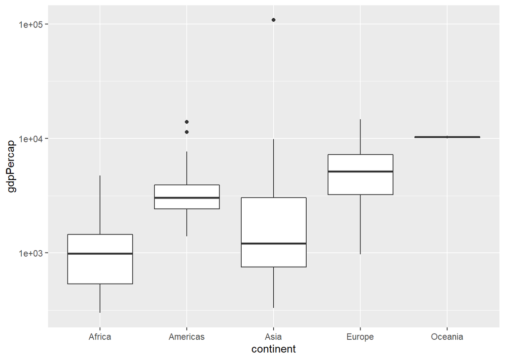

```r
gapminder_1952 <- gapminder %>%
  filter(year == 1952)

# Create a boxplot comparing gdpPercap among continents
ggplot(gapminder_1952, aes(x = continent, y = gdpPercap)) +
      geom_boxplot() +
      scale_y_log10()
```

# Exercicio *Adding a title to your graph*

There are many other options for customizing a ggplot2 graph, which you can learn about in other DataCamp courses. You can also learn about them from online resources, which is an important skill to develop.

As the final exercise in this course, you’ll practice looking up ggplot2 instructions by completing a task we haven’t shown you how to do.

Add a title to the graph: Comparing GDP per capita across continents. Use a search engine, such as Google or Bing, to learn how to do so.

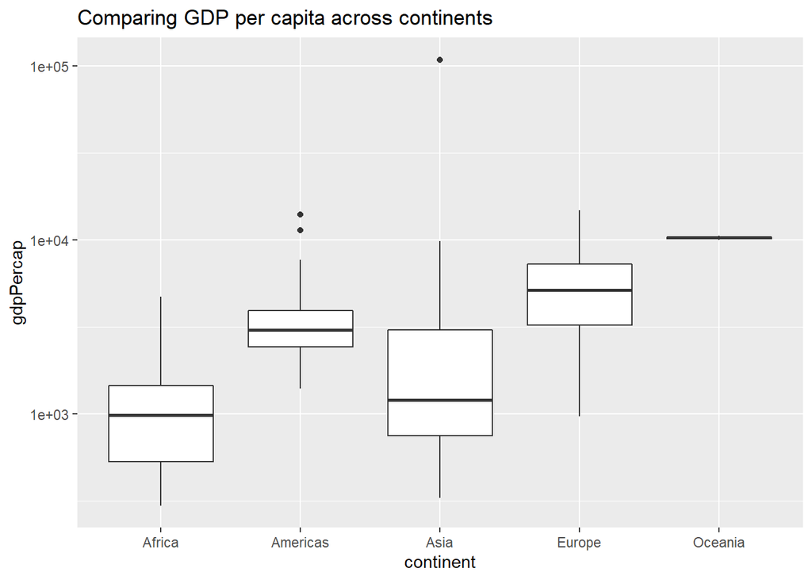

```r
# Add a title to this graph: "Comparing GDP per capita across continents"
p <- ggplot(gapminder_1952, aes(x = continent, y = gdpPercap)) +
  geom_boxplot() +
  scale_y_log10()

# Add titles
g <- p + labs(title = "Comparing GDP per capita across continents")
g
```

```r
# Observe que precisamos da camada labs()
```

## DATA VISUALIZATION WITH GGPLOT2 - 5h

## IMPORTING & CLEANING DATA - 14h

## EXPLORATORY DATA ANALYSIS IN R: CASE STUDY